# R Notebook

# Cox PH assumption: proportional hazard

Survival curves for two strata, determined by values of the predictors (Tx arm) in a linear regression settings, must have hazard functions that are proportional over time (i.e. constant relative hazard).

However, in immunotherapy trials, pfs or os curves often separate at later times, rather than as a constant process, which violate the proportional-hazards assumption.

When results deviate from proportional hazards, an elementary non-proportional-hazards analysis (excluding 20% of early events) generally results in more significant p-values.

A variety of more sophisticated methods for avoiding or relaxing proportional-hazards assumptions are available - for example: restricted mean survival methods and methods for delayed treatment effects.

https://rpubs.com/alecri/258589

# data & pkgs

```r
ggplotly(
  orca %>%
    mutate(
      text = paste("Subject ID = ", id, "<br>", "Time = ", time, "<br>", "Event = ",
                   event, "<br>", "Age = ", round(age, 2), "<br>", "Stage = ", stage)
    ) %>%
  ggplot(aes(x = id, y = time, text = text)) +
    geom_linerange(aes(ymin = 0, ymax = time)) +
    geom_point(aes(shape = event, color = event), stroke = 1, cex = 2) +
    scale_shape_manual(values = c(1, 3, 4)) +
    labs(y = "Time (years)", x = "Subject ID") + coord_flip() + theme_classic(),
  tooltip = "text"
)
```

```
We recommend that you use the dev version of ggplot2 with `ggplotly()`
Install it with: `devtools::install_github('hadley/ggplot2')`
```

[interactive chart not shown]

# non-parametric estimators

1. Kaplan-Meier estimator: below
2. Nelson-Aalen estimator

|  | time | n.risk | n.event | n.censor | surv | std.err | upper | lower |
| --- | --- | --- | --- | --- | --- | --- | --- | --- |
| 1 | 0.085 | 267 | 2 | 0 | 0.9925094 | 0.005316630 | 1.0000000 | 0.9822207 |
| 2 | 0.162 | 265 | 1 | 0 | 0.9887640 | 0.006523836 | 1.0000000 | 0.9762017 |
| 3 | 0.167 | 264 | 2 | 0 | 0.9812734 | 0.008454321 | 0.9976687 | 0.9651475 |
| 4 | 0.170 | 262 | 1 | 0 | 0.9775281 | 0.009278969 | 0.9954685 | 0.9599110 |
| 5 | 0.249 | 261 | 1 | 0 | 0.9737828 | 0.010041688 | 0.9931380 | 0.9548048 |
| 6 | 0.252 | 260 | 2 | 0 | 0.9662921 | 0.011430251 | 0.9881842 | 0.9448851 |

# parametric estimators

```r
flexsurvreg(su_obj ~ 1, data = orca, dist = "exponential")
flexsurvreg(su_obj ~ 1, data = orca, dist = "weibull")
```

[output not shown]

# Cox PH model

The semi-parametric nature of the Cox model is that the baseline rate may vary over time and it is not required to be estimated. The major assumption of the Cox model is that the hazard ratio for a predictor $Z_i$ is constant ($exp^{\beta_i}$) and does not depend on the time, i.e. the hazards in the two groups are proportional over time.

```r
fit.cox = coxph(su_obj ~ sex + I((age-65)/10) + st3, data = orca)
summary(fit.cox)
cox.zph(fit.cox)
round(ci.exp(fit.cox), 4)

fit.weibull = flexsurvreg(su_obj ~ sex + I((age-65)/10) + st3, data = orca, dist = "weibull")
fit.weibull
```

[output not shown]

> Parameters of Cox PH models are interpretaed as hazard ratio, while parameters of Weibull models are interpreted as survival time

> i.e. Cox parameter of sexMale 1.3284 means hazard rate of male is 32.8% more then females; Weibull parameter of sexMale 0.71245 means survival time of men are 71.2% of females.

# Cox models is mathematically equivalent to a Poisson regression model on a particular transformation of the data

# aka: piecewise exponential models

Transformation: split the follow-up time every time an event is observed in such a way every time interval contains only one event

```r
coefs[! grepl("time", rownames(coefs)), ]
```

```
                  Estimate Std. Error  z value     Pr(>|z|)
sexMale          0.2839390 0.15710962 1.807267 7.072065e-02
I((age - 65)/10) 0.3800948 0.06214584 6.116175 9.584777e-10
st3III           0.3089216 0.18265210 1.691311 9.077734e-02
st3IV            0.8682713 0.17864331 4.860363 1.171708e-06
```

# Predictions

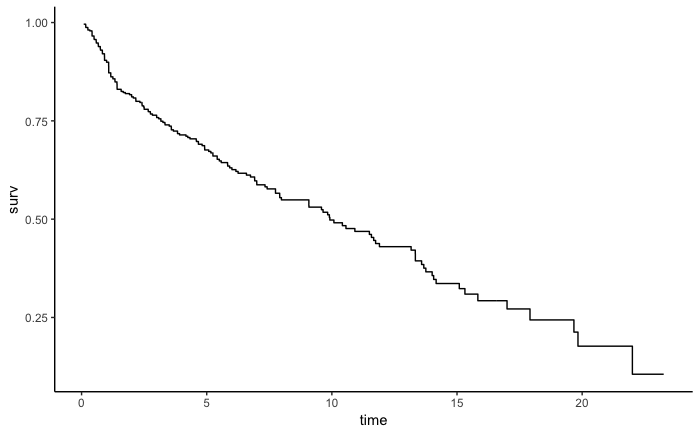

# Simulate time-to-event data

```r
N = 1e2 # sample size
lambda = 1e-2 # scale parameter
rho = 1 # shape parameter
beta = -0.6 # fixed effect parameter
rateC = 1e-3 # rate parameter of the exponential distribution of C

# covariate --> N Bernoulli trials
x <- sample(x=c(0, 1), size=N, replace=TRUE, prob=c(0.5, 0.5))

# Weibull latent event times
v <- runif(n=N)
Tlat <- (- log(v) / (lambda * exp(x * beta)))^(1 / rho)
hist(Tlat)

# censoring times
C <- rexp(n=N, rate=rateC)
hist(C)

# follow-up times and event indicators
time <- pmin(Tlat, C)
status <- as.numeric(Tlat <= C)

plot(survfit(Surv(time, status) ~ 1))

fit <- coxph(Surv(time, status) ~ x)
fit$coefficients
```

[output not shown]